# Análise: Nível de Hidrocarboneto x Pureza

## Bootstrap Paramétrico

Temos a seguinte hipótese:

$$\begin{array}{ccc}
H_0: \beta1 = 0 \\
H_0: \beta1 \neq 0
\end{array}$$

E considerando que os nossos dados seguem um modelo de regressão linear, temos:

$$PUREZA = \beta0 + \beta1*NIVEL\_HIDROCARBONETO + ERRO$$

Onde erro é:

$$ERRO \thicksim N(0;\sigma^2)$$

### - Realizando a leitura dos dados:

```r
rawdata <- readxl::read_excel('nivel_hidrocarboneto_data.xlsx')
```

```
-
/
```

```r
head(rawdata)
```

| NIVEL_HIDROCARBONETO | PUREZA |
| --- | --- |
| 0.99 | 90.01 |
| 1.02 | 89.05 |
| 1.15 | 91.43 |
| 1.29 | 93.74 |
| 1.46 | 96.73 |
| 1.36 | 94.45 |

Plotando um gráfico de relação dispersão entre as variáves Nível de Hidrocarboneto e pureza com uma linha de dentência observamos na Figura abaixo um relação linear entre as duas variáveis.

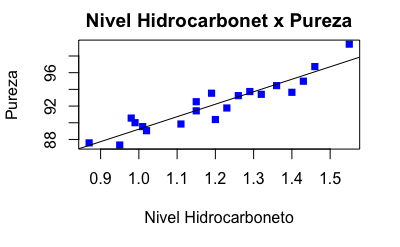

```r
plot(rawdata$NIVEL_HIDROCARBONETO,rawdata$PUREZA, xlab="Nivel Hidrocarboneto", ylab="Pureza", main="Nivel Hidrocarbonet x Pureza", pch=15, col="blue")
U <- lm(rawdata$PUREZA ~ rawdata$NIVEL_HIDROCARBONETO)
abline(U)
```

Com isso, podemos ter o valor de $\beta0$ e $\beta1$:

```r
beta0 <- U$coefficients[1]
beta0
```

```
(Intercept)
   74.28331
```

```r
beta1 <- U$coefficients[2]
beta1
```

```
rawdata$NIVEL_HIDROCARBONETO
                    14.94748
```

```r
W <- summary(U)
W
```

```
Call:
lm(formula = rawdata$PUREZA ~ rawdata$NIVEL_HIDROCARBONETO)

Residuals:
     Min       1Q   Median       3Q      Max
-1.83029 -0.73334  0.04497  0.69969  1.96809

Coefficients:
                             Estimate Std. Error t value Pr(>|t|)
(Intercept)                    74.283      1.593   46.62  < 2e-16 ***
rawdata$NIVEL_HIDROCARBONETO   14.947      1.317   11.35 1.23e-09 ***
---
Signif. codes:  0 '***' 0.001 '**' 0.01 '*' 0.05 '.' 0.1 ' ' 1

Residual standard error: 1.087 on 18 degrees of freedom
Multiple R-squared:  0.8774,    Adjusted R-squared:  0.8706
F-statistic: 128.9 on 1 and 18 DF,  p-value: 1.227e-09
```

```r
beta1.sd <- W$coefficients[4]
beta1.sd
```

```
[1] 1.316758
```

```r
Tobs <- beta1 / beta1.sd
paste('Tobs = ', Tobs)
```

```
[1] "Tobs =  11.3517264901251"
```

**Logo**:

$\widehat{PUREZA} = 74.28331 + 14.94748 * NIVEL\_HIDROCARBONETO$.

**E**

$RESIDUO = Y - \widehat{Y}$

```r
U$residuals
```

```
          1           2           3           4           5           6           7           8           9          10
 0.92868082 -0.47974357 -0.04291593  0.17443691  0.62336535 -0.16188668  0.30237839 -0.89871431  1.96809217 -1.55978587
         11          12          13          14          15          16          17          18          19          20
 1.46918488  1.04708407  1.62815562  0.15973123 -1.02501674 -1.83028992  0.13286130 -0.60398749 -0.67821026 -1.15341999
```

**E**

$$\sigma^2 = (\sum r_i^2) / n - 2 = 1,180545382 \\
\sigma = \sqrt{\sigma^2} = 1,086529053$$

```r
sigma <- summary(U)$sigma
paste('Sigma = ',sigma)
variancia <- sigma^2
paste('Variancia = ',variancia)
```

[output not shown]

### - Realizando simulação Bootstrap

Executando a simulação n vezes e armazenando o resultado:

```r
corridas <- 5000
GG <- matrix(0, corridas, 1)
for(i in 1:corridas){
  #Sob H0 temos B1=0
  Y <- beta0 + 0 * rawdata$NIVEL_HIDROCARBONETO + rnorm(length(rawdata$NIVEL_HIDROCARBONETO), 0, sigma)
  Reg <- lm(Y ~ rawdata$NIVEL_HIDROCARBONETO)
  W1 <- summary(Reg)
  GG[i,1] <- Reg$coefficients[2]
}
```

```r
LimitesA <- quantile(GG[,1]/(var(GG[,1])^0.5), c(.025, .975))
printf(c("LI = %f", "|| LS = %f\n"), LimitesA)

pvalue <- 2*mean(GG[,1]/(var(GG[,1])^0.5)>Tobs)
paste('p-value = ', pvalue)
```

[output not shown]

Como $T_obs (11.3517264901251) > LS (1.818325)$ então Rejeitamos $H_0: beta1 = 0$ ao nível de 5% de significância ou confiança de 95%. p-value calculado foi de 0.

O histograma de GG[,1] terá aproximadamente uma distribuição T com n-2 gl.

```r
hist(GG[, 1])
```

[output not shown]

## Bootstrap Não Paramétrico

Observe que nossas as análises anteriores usamos a Hipótese de que os resíduos são normais (indicativo que o erro é normal). E se os resíduos não forem normais usaremos o **Bootstrap Não Paramétrico**.

Isto significa que não podemos usar a normalidade dos resíduos. Portanto, no momento de realizar o experimento temos que substituir para uma amostra aleatória, ou seja, trocamos o método *rnomr* por *sample*, conforme exemplo abaixo:

```r
corridas <- 50000
GG <- matrix(0, corridas, 1)
n <- length(rawdata$NIVEL_HIDROCARBONETO)
for(i in 1:corridas){
  #Sob H0 temos B1=0
  Y <- beta0 + 0 * rawdata$NIVEL_HIDROCARBONETO + sample(U$residuals, n, replace = TRUE)
  Reg <- lm(Y ~ rawdata$NIVEL_HIDROCARBONETO)
  W1 <- summary(Reg)
  GG[i,1] <- Reg$coefficients[2] / beta1.sd
}
```

```r
LimitesA <- quantile(GG[,1], c(.025, .975))
printf(c("LI = %f", "|| LS = %f\n"), LimitesA)
```

```
LI = 0.162315 || LS = 2.990810
```

```r
pvalue <- 2 * mean( GG[,1] > Tobs)
printf("p-value = %.10f", pvalue)
```

```
p-value = 0.0000000000
```